# Assistência Técnica Pública e Privada · Sistemas de ATER no Brasil

Extensão Rural

Prof. Dr. Luiz Diego Vidal Santos

## Abertura Visão Geral da Aula

Roteiro da aula Tópicos principais

- 1 ATER Pública — EMATER e Estaduais
- 2 ATER Privada — Consultorias e Revendas
- 3 Sistema S — SENAR e SEBRAE
- 4 Cooperativas, Associações e ONGs
- 5 Desafios, Conflitos e Complementaridades

Objetivo da aula Sistemas de ATER no Brasil

Comparar os diferentes sistemas de assistência técnica e extensão rural no Brasil, analisando suas abordagens, públicos-alvo, fontes de financiamento e efetividade na promoção do desenvolvimento rural.

EMATER · PNATER SENAR · SEBRAE Cooperativas · ONGs

Da arquitetura plural da ATER brasileira aos desafios de governança territorial e autonomia decisória.

# Arquitetura Institucional e ATER Pública

## Institucional O Sistema Plural de ATER no Brasil

Organização descentralizada Pluralidade institucional

A assistência técnica e extensão rural no Brasil se organiza em um **sistema plural e descentralizado**, composto por entidades públicas, privadas e do terceiro setor.

A **Lei 12.188/2010** (PNATER) estabeleceu o marco legal que reconhece essa pluralidade institucional, priorizando a **agricultura familiar** como público preferencial da ATER pública.

Linha do tempo normativa Marcos Legais

- **Lei 6.126/74** — Criação da EMBRATER
- **Lei 8.447/92** — Extinção da EMBRATER
- **Lei 12.188/2010** — PNATER
- **Decreto 7.215/2010** — PRONATER

O reconhecimento jurídico da pluralidade exige mecanismos de coordenação pública para evitar sobreposição de ações e lacunas de atendimento.

## Matriz Arquitetura Institucional da ATER no Brasil

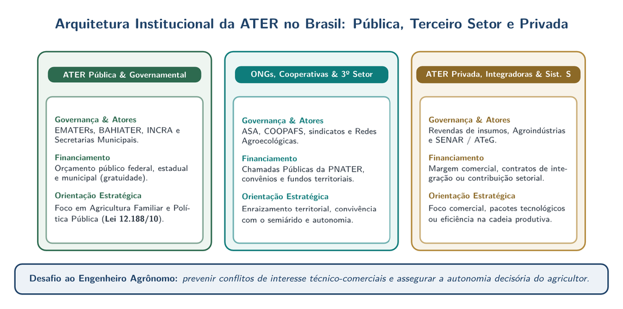

Matriz institucional da ATER no Brasil comparando setor público, terceiro setor e setor privado.

Arquitetura Institucional da ATER no Brasil: Pública, Terceiro Setor e Privada Comparação de governança, financiamento e orientação estratégica entre provedores (Lei 12.188/10)

## Histórico ATER Pública: Origem e Trajetória (1948–1990)

**1948 — ACAR (MG):** criação da primeira agência de extensão rural no país, com apoio da **Associação Internacional Americana (AIA)**, do grupo Rockefeller.

**1956 — ABCAR:** fundação da Associação Brasileira de Crédito e Assistência Rural, articulando agências estaduais.

**1974 — Lei 6.126 (EMBRATER):** estatização e centralização do sistema nacional de extensão rural.

**1990 — Extinção da EMBRATER:** extinção no governo Collor desencadeou crise que fragmentou o sistema público de ATER.

[figure not shown]

Logotipo da EMATER-MG, referência estadual em assistência técnica e extensão rural.

EMATER-MG · Referência em ATER pública CC-BY-SA 4.0 · EMATER-MG / Wikimedia

A partir dos anos 1990, a descentralização transferiu aos estados a responsabilidade direta pela continuidade dos serviços públicos de extensão.

## Estaduais ATER Pública: EMATER e Entidades Estaduais

Após a extinção da EMBRATER, cada estado passou a gerir suas próprias entidades e arranjos de ATER:

[output not shown]

**Características comuns:** gratuidade, foco na agricultura familiar, capilaridade municipal e vínculo com os princípios da PNATER.

## Alerta ATER Pública: Gargalos Estruturais e Cobertura

Gargalos estruturais Limites operacionais crônicos

A ATER pública enfrenta desafios que comprometem sua efetividade:

- Déficit de extensionistas (1 para cada 800+ agricultores em muitos estados)
- Infraestrutura precária (veículos, escritórios, conectividade)
- Descontinuidade de políticas a cada ciclo eleitoral
- Baixa remuneração e envelhecimento do quadro técnico

Censo Agropecuário IBGE (2017) Dados relevantes de cobertura

Os números oficiais revelam forte desigualdade regional:

- Apenas **20,2%** dos estabelecimentos da agricultura familiar receberam algum tipo de assistência técnica
- Nos estados do Nordeste, essa proporção cai para menos de **10%** em algumas UFs
- O principal provedor para a agricultura familiar continua sendo o **governo** (federal e estadual)

# ATER Privada e Sistema S

## Privada ATER Privada: Consultorias e AgTechs

A ATER privada atua predominantemente junto ao **agronegócio** e à **agricultura empresarial**.

Segmentos de atuação Modalidades

- Consultorias agronômicas independentes
- Departamentos técnicos de revendas de insumos
- Empresas de agricultura de precisão
- Startups agrotechs (AgTechs)

Financiamento e limitação Assimetria comercial

**Financiamento:** custeado pelo próprio produtor ou vinculado à venda de insumos e serviços.

**Limitação:** frequentemente se confunde com **assistência técnica comercial** — o extensionista é, na prática, um vendedor de tecnologias.

## Alerta ATER Privada: Revendas e Conflito de Interesses

Modelo de negócio Assistência vinculada à compra

Muitos agricultores recebem assistência técnica **vinculada** à compra de insumos:

- Defensivos (assistência técnica de receituário)
- Sementes e fertilizantes (consultoria de manejo)
- Máquinas agrícolas (treinamento operacional)

O produtor não paga diretamente pela AT, mas ela está **embutida** no preço do produto.

Conflito de interesses (Peixoto, 2008) Risco estrutural

Há risco estrutural quando a AT é ofertada por quem vende insumos:

- Viés em direção a **pacotes tecnológicos** próprios
- Desconsideração de alternativas agroecológicas
- Foco no **produto**, não no **sistema produtivo**

A ATER privada vinculada a revendas tende a reproduzir o modelo **difusionista** criticado por Paulo Freire.

## Sistema S Sistema S: SENAR e SEBRAE

Lei 8.315/1991 · Contribuição setorial SENAR — Formação e ATeG

Financiado por contribuição compulsória sobre a folha do setor agropecuário. Atua em **Formação Profissional Rural (FPR)**, **Promoção Social (PS)** e **Assistência Técnica e Gerencial (ATeG)** desde 2014.

Atende agricultura familiar e empresarial, com foco em **gestão da propriedade** e **aumento de produtividade** via visitas periódicas e metas de indicadores (sistema de pontuação).

Gestão e acesso a mercados SEBRAE — Empreendedorismo rural

Atua no meio rural com foco em **empreendedorismo e gestão de negócios**:

- Capacitação em acesso a mercados
- Formalização de agroindústrias familiares
- Planos de negócios para cooperativas
- Certificação de origem e selos de qualidade

Atua em parceria com EMATER, cooperativas e prefeituras, complementando a dimensão **gerencial e mercadológica**.

# Cooperativas, ONGs e Comparativo

## Terceiro Setor Cooperativas, Associações e ONGs

01 · Intermediação Cooperativas Agropecuárias

Oferecem assistência técnica aos cooperados, acesso a insumos com preços negociados, canais de comercialização, armazenagem e beneficiamento.

02 · Horizontalidade Modelo Cooperativo Familiar

Extensionista membro da comunidade, valorização do saber local, foco em **sistemas produtivos integrados** e alinhamento com a **PNATER** (ex.: reforma agrária).

03 · Baixa cobertura estatal ONGs no Nordeste

**AS-PTA**, **MOC (BA)**, **SASOP (BA)** e **Centro Sabiá (PE)**. Financiamento via cooperação internacional, chamadas ATER/MDA e parcerias estaduais.

## Comparativo Comparativo Institucional dos Sistemas de ATER

| Critério | EMATER/Estaduais | SENAR | Privada/Revendas | Cooperativas | ONGs |
| --- | --- | --- | --- | --- | --- |
| **Público** | Agricultura familiar | Todos | Empresarial | Cooperados | Comunidades |
| **Custo** | Gratuito | Gratuito | Embutido/pago | Taxa cooperativa | Gratuito |
| **Abordagem** | Participativa | Gerencial | Difusionista | Horizontal | Agroecológica |
| **Capilaridade** | Alta (municipal) | Média | Variável | Local | Pontual |
| **Continuidade** | Baixa (política) | Média | Alta (mercado) | Média | Baixa (projetos) |

Cada arranjo institucional combina forças e limites distintos quanto a custo, escala, continuidade e postura metodológica.

## Articulação Complementaridades e Conflitos no Território

Pluralidade virtuosa Complementaridades

Quando há **articulação** interinstitucional, cada ator potencializa o sistema:

- **EMATER:** diagnóstico e planejamento participativo
- **SENAR:** capacitação gerencial e técnica
- **Cooperativas:** comercialização e escala
- **ONGs:** metodologias participativas e agroecologia

Falta de coordenação Conflitos e lacunas

A ausência de pactuação territorial gera **sobreposição e lacunas**:

- Disputa por público entre entidades
- Abordagens contraditórias (agroecologia × pacote tecnológico)
- Desarticulação territorial
- Fraca integração com pesquisa (Embrapa, universidades)

# Governança, Síntese e Referências

## Futuro Perspectivas para a Governança Territorial da ATER

**Conselhos Municipais de Desenvolvimento Rural:** espaços institucionalizados de pactuação territorial.

**Chamadas públicas de ATER:** editais que valorizem resultados qualitativos e impacto social, não apenas metas quantitativas.

**Integração com pesquisa:** articulação orgânica com Embrapa, universidades e Institutos Federais (IFs).

**ATER Digital transversal:** uso de ferramentas digitais integrado a todos os provedores sem excluir públicos vulneráveis.

**Formação continuada:** qualificação permanente de extensionistas públicos e privados em comunicação e agroecologia.

O desafio não é escolher entre ATER pública ou privada, mas construir um **sistema integrado** que atenda à diversidade do campo brasileiro.

## Síntese Conclusão: Um Sistema Plural, Descentralizado e Desigual

Síntese dos subsistemas Forças e tensões atuais

- A **ATER pública** garante alcance à agricultura familiar, mas sofre com a precarização.
- A **ATER privada** é eficiente para o agronegócio, mas reproduz o modelo difusionista.
- O **Sistema S** oferece capacitação gerencial, porém com cobertura limitada.
- **Cooperativas e ONGs** inovam em metodologia, mas dependem de financiamento externo.

Papel do engenheiro agrônomo Atuação integradora

O engenheiro agrônomo deve estar preparado para atuar em **qualquer um desses espaços**, articulando saberes técnicos, sociais e comunicacionais para uma extensão rural efetiva e inclusiva.

**Compromisso profissional:** prevenir conflitos de interesse técnico-comerciais e assegurar a autonomia decisória do agricultor.

## Referências Referências Bibliográficas e Marcos Legais

Legislação e estatísticas oficiais Marcos legais e censos

- Brasil. Lei 6.126/74 — EMBRATER (1974)
- Brasil. Lei 8.315/91 — SENAR (1991)
- Brasil. Lei 8.447/92 — Extinção da EMBRATER (1992)
- Brasil. Lei 12.188/2010 — PNATER/PRONATER (2010)
- IBGE. *Censo Agropecuário 2017* (2019)

Literatura científica Referências teóricas

- Caporal, F. R.; Ramos, L. F. *Da extensão rural convencional à extensão rural para o desenvolvimento sustentável* (2006)
- Freire, P. *Extensão ou Comunicação* (1979)
- Peixoto, M. *Extensão rural no Brasil* (2008)